# Análisis exploratorio del Amazon Delivery Dataset

Grupo 3 – Proyecto Integrador II: Helena Ventura-Travesset, Javier Gaudencio Ortega, Sara Miguel Winterburn, Fernando San Prudencio

19/04/2026

## Introducción

El presente informe recoge el análisis exploratorio del *Amazon Delivery Dataset*, que contiene registros reales de entregas realizadas por Amazon en varias ciudades de la India durante el año 2022. El objetivo de este análisis es comprender la estructura del conjunto de datos, identificar los factores que influyen en el tiempo de entrega y extraer conclusiones útiles para el posterior desarrollo del sistema de optimización de rutas.

```r
data <- read.csv("amazon_delivery.csv", stringsAsFactors = FALSE)

# Limpieza básica de espacios en variables categóricas
data <- data %>%
  mutate(across(c(Traffic, Vehicle, Area, Weather, Category), str_trim))

# Eliminamos filas con valores críticos ausentes
data <- data %>% filter(!is.na(Delivery_Time))

cat("Registros totales:", nrow(data), "\n")
```

```
## Registros totales: 43739
```

```r
cat("Variables:", ncol(data), "\n")
```

```
## Variables: 16
```

## Estadística descriptiva

Antes de entrar en el análisis por factores, conviene describir las principales variables numéricas del dataset para tener una imagen global de su distribución.

```r
resumen <- data %>%
  summarise(
    `Media (min)`     = round(mean(Delivery_Time, na.rm = TRUE), 1),
    `Mediana (min)`   = median(Delivery_Time, na.rm = TRUE),
    `Desv. típica`    = round(sd(Delivery_Time, na.rm = TRUE), 1),
    `Mínimo (min)`    = min(Delivery_Time, na.rm = TRUE),
    `Máximo (min)`    = max(Delivery_Time, na.rm = TRUE)
  )

kable(resumen, caption = "Estadísticas descriptivas de Delivery_Time")
```

Estadísticas descriptivas de Delivery_Time

| Media (min) | Mediana (min) | Desv. típica | Mínimo (min) | Máximo (min) |
| --- | --- | --- | --- | --- |
| 124.9 | 125 | 51.9 | 10 | 270 |

La distribución del tiempo de entrega se puede visualizar con mayor detalle a través de su histograma:

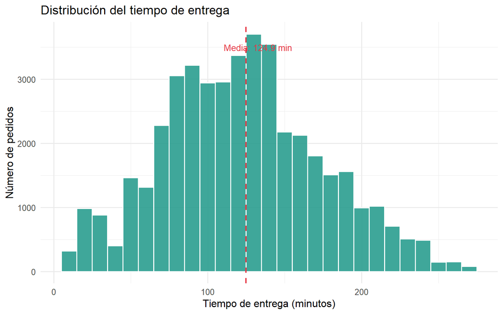

```r
ggplot(data, aes(x = Delivery_Time)) +
  geom_histogram(binwidth = 10, fill = "#2A9D8F", color = "white", alpha = 0.9) +
  geom_vline(aes(xintercept = mean(Delivery_Time, na.rm = TRUE)),
             color = "#E63946", linetype = "dashed", linewidth = 0.8) +
  annotate("text", x = mean(data$Delivery_Time, na.rm = TRUE) + 8,
           y = 3500, label = paste0("Media: ", round(mean(data$Delivery_Time, na.rm = TRUE), 1), " min"),
           color = "#E63946", size = 3.5) +
  labs(title = "Distribución del tiempo de entrega",
       x = "Tiempo de entrega (minutos)", y = "Número de pedidos") +
  theme_minimal(base_size = 12)
```

## Factores que afectan al tiempo de entrega

### Tráfico

El nivel de tráfico es probablemente el factor operativo más determinante en la duración de una entrega urbana. El siguiente gráfico muestra la distribución del tiempo de entrega según cada nivel de congestión registrado.

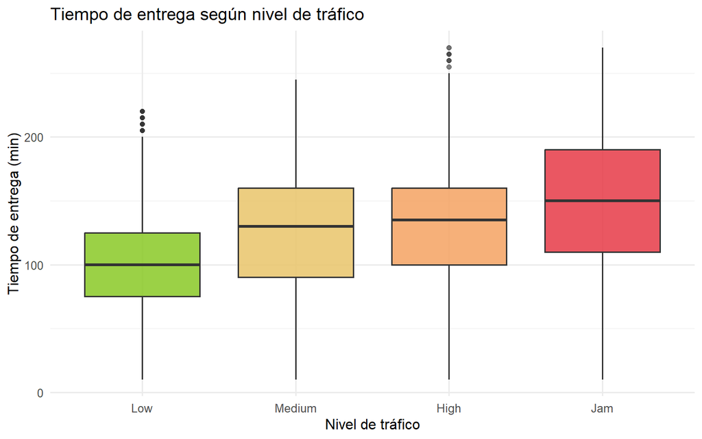

```r
data %>%
  filter(Traffic != "NaN") %>%
  mutate(Traffic = factor(Traffic, levels = c("Low", "Medium", "High", "Jam"))) %>%
  ggplot(aes(x = Traffic, y = Delivery_Time, fill = Traffic)) +
  geom_boxplot(alpha = 0.85, outlier.alpha = 0.2) +
  scale_fill_manual(values = c("#8AC926", "#E9C46A", "#F4A261", "#E63946")) +
  labs(title = "Tiempo de entrega según nivel de tráfico",
       x = "Nivel de tráfico", y = "Tiempo de entrega (min)") +
  theme_minimal(base_size = 12) +
  theme(legend.position = "none")
```

```r
data %>%
  filter(Traffic != "NaN") %>%
  mutate(Traffic = factor(Traffic, levels = c("Low", "Medium", "High", "Jam"))) %>%
  group_by(Traffic) %>%
  summarise(
    Media    = round(mean(Delivery_Time), 1),
    Mediana  = median(Delivery_Time),
    `Desv. típica` = round(sd(Delivery_Time), 1),
    N        = n()
  ) %>%
  kable(caption = "Tiempo de entrega medio por nivel de tráfico")
```

Tiempo de entrega medio por nivel de tráfico

| Traffic | Media | Mediana | Desv. típica | N |
| --- | --- | --- | --- | --- |
| Low | 101.4 | 100 | 38.8 | 14999 |
| Medium | 126.8 | 130 | 48.7 | 10628 |
| High | 129.4 | 135 | 48.3 | 4296 |
| Jam | 147.8 | 150 | 56.8 | 13725 |

### Condiciones meteorológicas

Las condiciones climáticas pueden dificultar tanto la conducción como el acceso a los puntos de entrega, incrementando los tiempos de servicio.

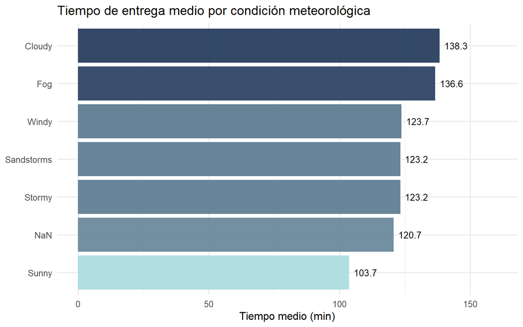

```r
data %>%
  filter(!is.na(Weather)) %>%
  group_by(Weather) %>%
  summarise(media = mean(Delivery_Time, na.rm = TRUE), n = n()) %>%
  arrange(desc(media)) %>%
  ggplot(aes(x = reorder(Weather, media), y = media, fill = media)) +
  geom_col(show.legend = FALSE, alpha = 0.9) +
  geom_text(aes(label = round(media, 1)), hjust = -0.2, size = 3.5) +
  coord_flip() +
  scale_fill_gradient(low = "#A8DADC", high = "#1D3557") +
  labs(title = "Tiempo de entrega medio por condición meteorológica",
       x = NULL, y = "Tiempo medio (min)") +
  theme_minimal(base_size = 12) +
  ylim(0, 160)
```

### Tipo de vehículo

El vehículo empleado condiciona tanto la velocidad de desplazamiento como la capacidad de carga, dos variables directamente relacionadas con la eficiencia de la ruta.

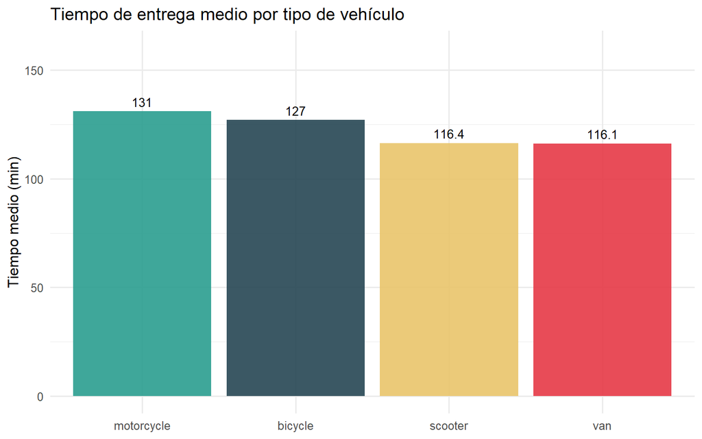

```r
data %>%
  group_by(Vehicle) %>%
  summarise(media = mean(Delivery_Time, na.rm = TRUE), n = n()) %>%
  ggplot(aes(x = reorder(Vehicle, -media), y = media, fill = Vehicle)) +
  geom_col(alpha = 0.9, show.legend = FALSE) +
  geom_text(aes(label = round(media, 1)), vjust = -0.5, size = 3.5) +
  scale_fill_manual(values = c("#264653", "#2A9D8F", "#E9C46A", "#E63946")) +
  labs(title = "Tiempo de entrega medio por tipo de vehículo",
       x = NULL, y = "Tiempo medio (min)") +
  theme_minimal(base_size = 12) +
  ylim(0, 160)
```

## Rendimiento de los repartidores

### Distribución de edad y valoración

Los repartidores quedan caracterizados en el dataset por su edad y su valoración media como agentes. Ambas variables pueden estar relacionadas con la eficiencia en la entrega.

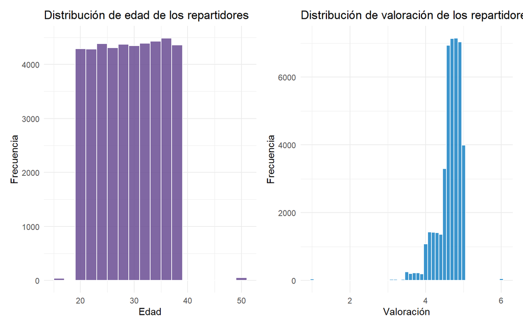

```r
p1 <- ggplot(data, aes(x = Agent_Age)) +
  geom_histogram(binwidth = 2, fill = "#6A4C93", color = "white", alpha = 0.85) +
  labs(title = "Distribución de edad de los repartidores",
       x = "Edad", y = "Frecuencia") +
  theme_minimal(base_size = 11)

p2 <- data %>%
  filter(!is.na(Agent_Rating)) %>%
  ggplot(aes(x = Agent_Rating)) +
  geom_histogram(binwidth = 0.1, fill = "#1982C4", color = "white", alpha = 0.85) +
  labs(title = "Distribución de valoración de los repartidores",
       x = "Valoración", y = "Frecuencia") +
  theme_minimal(base_size = 11)

library(patchwork)
p1 + p2
```

### Relación entre valoración y tiempo de entrega

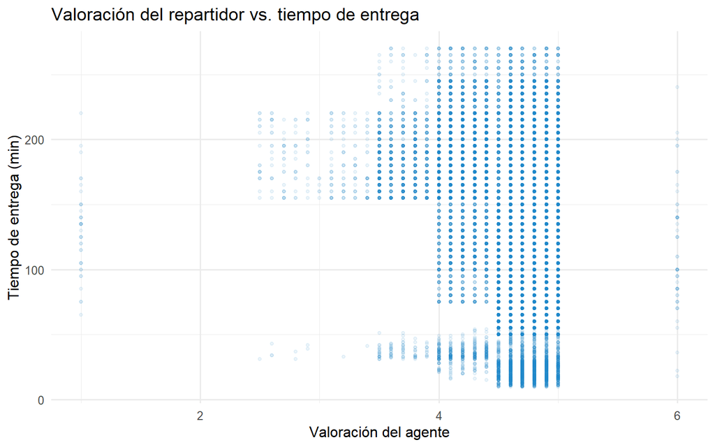

```r
data %>%
  filter(!is.na(Agent_Rating)) %>%
  ggplot(aes(x = Agent_Rating, y = Delivery_Time)) +
  geom_point(alpha = 0.08, color = "#1982C4", size = 1) +
  geom_smooth(method = "loess", color = "#E63946", linewidth = 1, se = TRUE) +
  labs(title = "Valoración del repartidor vs. tiempo de entrega",
       x = "Valoración del agente", y = "Tiempo de entrega (min)") +
  theme_minimal(base_size = 12)
```

### Relación entre edad y tiempo de entrega

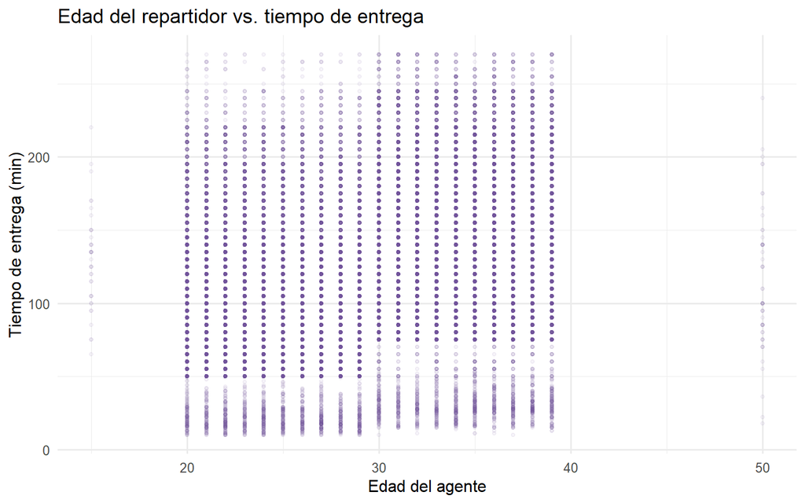

```r
data %>%
  ggplot(aes(x = Agent_Age, y = Delivery_Time)) +
  geom_point(alpha = 0.06, color = "#6A4C93", size = 1) +
  geom_smooth(method = "loess", color = "#E63946", linewidth = 1, se = TRUE) +
  labs(title = "Edad del repartidor vs. tiempo de entrega",
       x = "Edad del agente", y = "Tiempo de entrega (min)") +
  theme_minimal(base_size = 12)
```

## Comparativa entre zonas

Las características del entorno (metropolitano, urbano, semiurbano) determinan en gran medida la densidad de tráfico, la dispersión geográfica de los pedidos y, por ende, los tiempos de entrega. El siguiente análisis compara el comportamiento del servicio entre las distintas tipologías de zona.

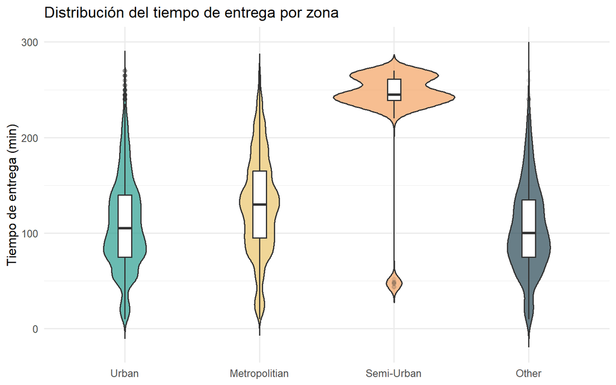

```r
data %>%
  mutate(Area = factor(Area, levels = c("Urban", "Metropolitian", "Semi-Urban", "Other"))) %>%
  ggplot(aes(x = Area, y = Delivery_Time, fill = Area)) +
  geom_violin(alpha = 0.7, trim = FALSE) +
  geom_boxplot(width = 0.1, fill = "white", outlier.alpha = 0.1) +
  scale_fill_manual(values = c("#2A9D8F", "#E9C46A", "#F4A261", "#264653")) +
  labs(title = "Distribución del tiempo de entrega por zona",
       x = NULL, y = "Tiempo de entrega (min)") +
  theme_minimal(base_size = 12) +
  theme(legend.position = "none")
```

```r
data %>%
  group_by(Area) %>%
  summarise(
    Media    = round(mean(Delivery_Time), 1),
    Mediana  = median(Delivery_Time),
    `Desv. típica` = round(sd(Delivery_Time), 1),
    `N pedidos`    = n()
  ) %>%
  arrange(desc(Media)) %>%
  kable(caption = "Estadísticas de tiempo de entrega por zona")
```

Estadísticas de tiempo de entrega por zona

| Area | Media | Mediana | Desv. típica | N pedidos |
| --- | --- | --- | --- | --- |
| Semi-Urban | 238.6 | 245 | 47.0 | 152 |
| Metropolitian | 129.7 | 130 | 51.6 | 32698 |
| Urban | 109.4 | 105 | 48.2 | 9751 |
| Other | 104.5 | 100 | 45.9 | 1138 |

También resulta interesante ver qué tipo de vehículo predomina en cada zona, ya que esto tiene implicaciones directas sobre la capacidad de carga y el diseño de las rutas.

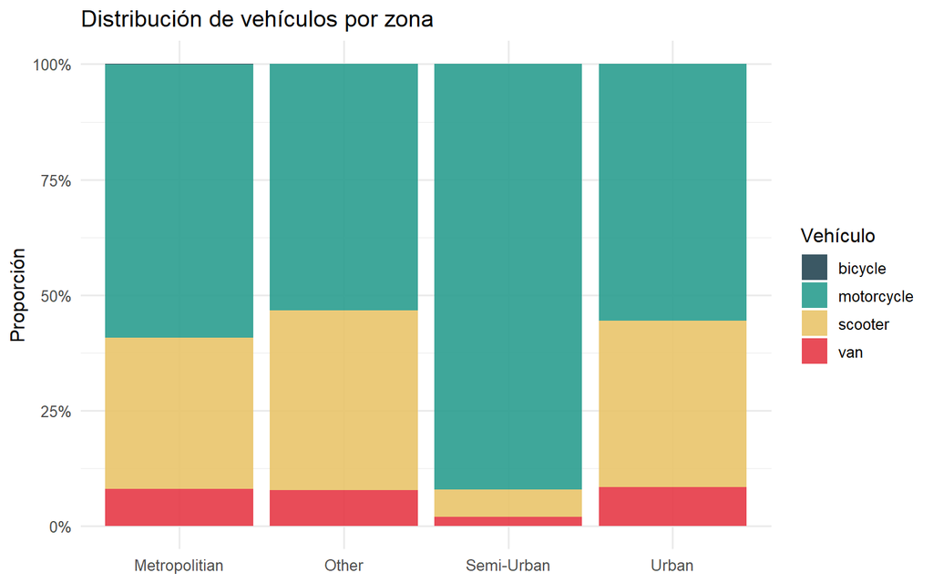

```r
data %>%
  count(Area, Vehicle) %>%
  group_by(Area) %>%
  mutate(pct = n / sum(n)) %>%
  ggplot(aes(x = Area, y = pct, fill = Vehicle)) +
  geom_col(position = "fill", alpha = 0.9) +
  scale_y_continuous(labels = percent_format()) +
  scale_fill_manual(values = c("#264653", "#2A9D8F", "#E9C46A", "#E63946")) +
  labs(title = "Distribución de vehículos por zona",
       x = NULL, y = "Proporción", fill = "Vehículo") +
  theme_minimal(base_size = 12)
```

## Distribución geográfica de los pedidos

Las coordenadas de origen (`Store`) y destino (`Drop`) permiten visualizar dónde se concentra la actividad de reparto y cuál es la distancia típica recorrida en cada entrega.

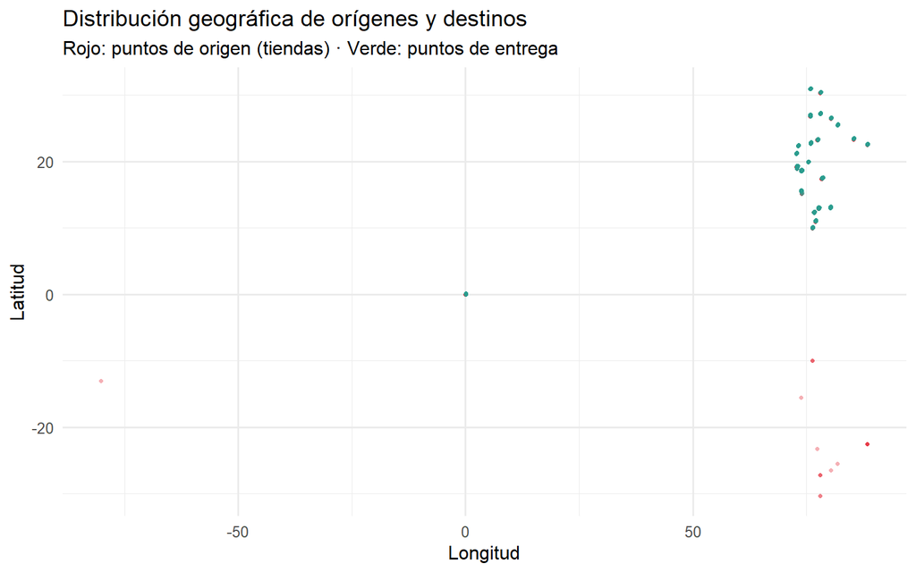

```r
data %>%
  sample_n(min(5000, nrow(data))) %>%
  ggplot() +
  geom_point(aes(x = Store_Longitude, y = Store_Latitude),
             color = "#E63946", alpha = 0.4, size = 0.8, shape = 16) +
  geom_point(aes(x = Drop_Longitude, y = Drop_Latitude),
             color = "#2A9D8F", alpha = 0.3, size = 0.8, shape = 16) +
  labs(title = "Distribución geográfica de orígenes y destinos",
       subtitle = "Rojo: puntos de origen (tiendas) · Verde: puntos de entrega",
       x = "Longitud", y = "Latitud") +
  theme_minimal(base_size = 12)
```

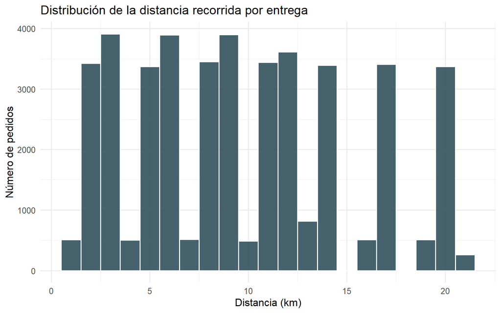

```r
# Cálculo de distancia haversine aproximada entre origen y destino
haversine <- function(lat1, lon1, lat2, lon2) {
  R <- 6371
  dlat <- (lat2 - lat1) * pi / 180
  dlon <- (lon2 - lon1) * pi / 180
  a <- sin(dlat/2)^2 + cos(lat1*pi/180) * cos(lat2*pi/180) * sin(dlon/2)^2
  R * 2 * atan2(sqrt(a), sqrt(1 - a))
}

data <- data %>%
  mutate(distancia_km = haversine(Store_Latitude, Store_Longitude,
                                   Drop_Latitude,  Drop_Longitude))

data %>%
  filter(distancia_km < quantile(distancia_km, 0.99)) %>%   # excluimos outliers extremos
  ggplot(aes(x = distancia_km)) +
  geom_histogram(binwidth = 1, fill = "#264653", color = "white", alpha = 0.85) +
  labs(title = "Distribución de la distancia recorrida por entrega",
       x = "Distancia (km)", y = "Número de pedidos") +
  theme_minimal(base_size = 12)
```

```r
data %>%
  filter(distancia_km < quantile(distancia_km, 0.99)) %>%
  group_by(Area) %>%
  summarise(
    `Distancia media (km)` = round(mean(distancia_km), 2),
    `Distancia mediana (km)` = round(median(distancia_km), 2)
  ) %>%
  kable(caption = "Distancia media recorrida por zona")
```

Distancia media recorrida por zona

| Area | Distancia media (km) | Distancia mediana (km) |
| --- | --- | --- |
| Metropolitian | 9.86 | 9.32 |
| Other | 9.11 | 8.94 |
| Semi-Urban | 12.82 | 12.58 |
| Urban | 9.03 | 7.80 |

## Correlaciones entre variables numéricas

Por último, analizamos la matriz de correlaciones entre las variables numéricas del dataset para identificar relaciones lineales de interés.

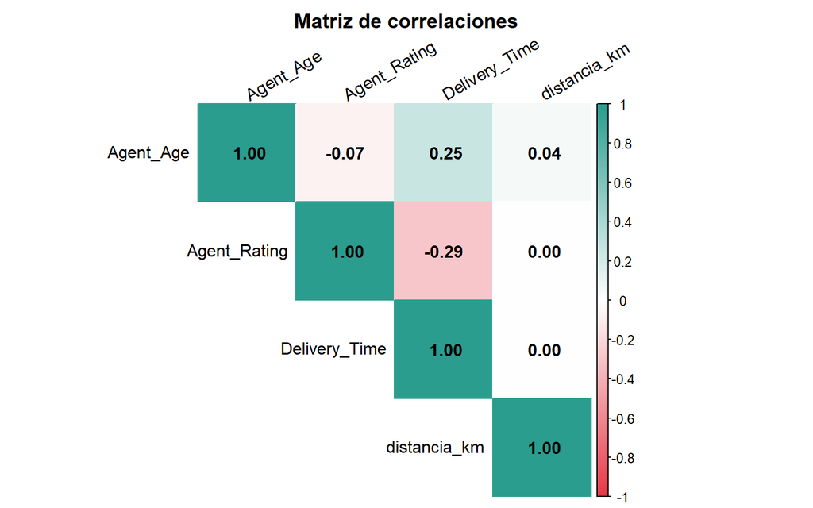

```r
vars_num <- data %>%
  select(Agent_Age, Agent_Rating, Delivery_Time, distancia_km) %>%
  filter(complete.cases(.))

cor_matrix <- cor(vars_num)

corrplot(cor_matrix,
         method   = "color",
         type     = "upper",
         addCoef.col = "black",
         tl.col   = "black",
         tl.srt   = 30,
         col      = colorRampPalette(c("#E63946", "white", "#2A9D8F"))(200),
         title    = "Matriz de correlaciones",
         mar      = c(0, 0, 2, 0))
```